# Feb 14 2018

## ANOVA with interaction

```r
vitaminb.1=aov(kidneyweight~ratsize*diet,
  data=vitaminb)
summary(vitaminb.1)
```

```
             Df Sum Sq Mean Sq F value   Pr(>F)
ratsize       1  8.068   8.068 141.179 1.53e-11 ***
diet          1  0.012   0.012   0.218    0.645
ratsize:diet  1  0.036   0.036   0.638    0.432
Residuals    24  1.372   0.057
---
Signif. codes:  0 ‘***’ 0.001 ‘**’ 0.01 ‘*’ 0.05 ‘.’ 0.1 ‘ ’ 1
```

Significance/nonsignificance as we expected. Note no significant interaction (can be removed).

### Interaction plot

- Plot mean of response variable against one of the explanatory, using other one as groups. Start from summary:

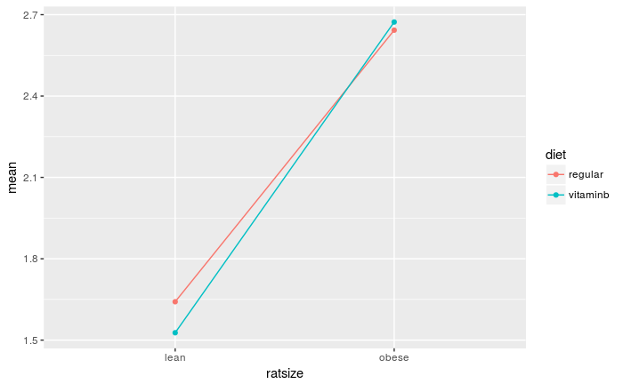

```r
ggplot(rat_means,aes(x=ratsize,y=mean,
     colour=diet,group=diet))+
  geom_point()+geom_line()
```

- For this, have to give *both* `group` and `colour`.

Lines basically parallel, indicating no interaction.

Another look: switch `diet` and `ratsize` around:

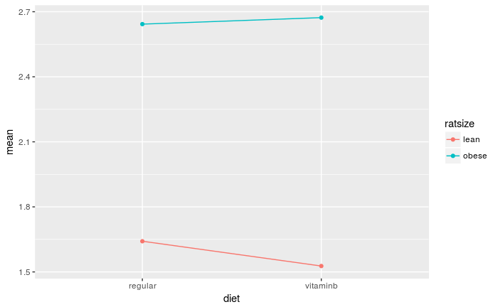

```r
ggplot(rat_means,aes(x=diet,y=mean,
     colour=ratsize,group=ratsize))+
  geom_point()+geom_line()
```

Again, two lines basically parallel.

### Take out interaction

Note notation `a:b` for “just the interaction between `a` and `b`”:

```r
vitaminb.2=update(vitaminb.1,.~.-ratsize:diet)
summary(vitaminb.2)
```

```
            Df Sum Sq Mean Sq F value   Pr(>F)
ratsize      1  8.068   8.068 143.256 7.59e-12 ***
diet         1  0.012   0.012   0.221    0.643
Residuals   25  1.408   0.056
---
Signif. codes:  0 ‘***’ 0.001 ‘**’ 0.01 ‘*’ 0.05 ‘.’ 0.1 ‘ ’ 1
```

### Tukey?

- No Tukey for `diet`: not significant.
- No Tukey for `ratsize`: only two sizes, and already know that obese rats have larger kidneys than lean ones.
- Bottom line: diet has no effect on kidney size once you control for size of rat.

## The auto noise data

In 1973, the President of Texaco cited an automobile filter developed by Associated Octel Company as effective in reducing pollution. However, questions had been raised about the effects of filter silencing. He referred to the data included in the report (and below) as evidence that the silencing properties of the Octel filter were at least equal to those of standard silencers.

Data: 36 engines, these variables:

- engine noise (response)
- size of engine (Large, Medium, Small)
- type of filter (Octel, Std)
- side: L or R (ignore)

```r
my_url="http://www.utsc.utoronto.ca/~butler/d29/autonoise.txt"
autonoise=read_table(my_url)
autonoise
```

| noise | size | type | side |
| --- | --- | --- | --- |
| 840 | M | Std | R |
| 770 | L | Octel | L |
| 820 | M | Octel | R |
| 775 | L | Octel | R |
| 825 | M | Octel | L |
| 840 | M | Std | R |
| 845 | M | Std | L |
| 825 | M | Octel | L |
| 815 | M | Octel | L |
| 845 | M | Std | R |

[output cut: 26 more lines]

### Use grouped boxplot again:

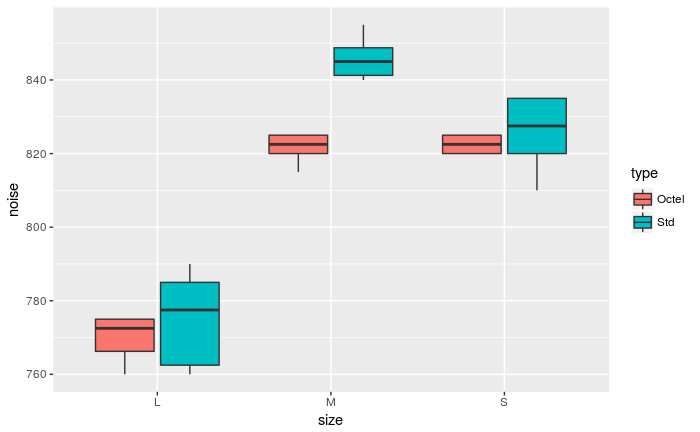

```r
autonoise %>%
    ggplot(aes(x=size,y=noise,fill=type))+
    geom_boxplot()
```

- Difference in engine noise between Octel and standard is larger for medium engine size than for large or small.
- Some evidence of differences in spreads (ignore for now).

### ANOVA

```r
autonoise.1=aov(noise~size*type,data=autonoise)
summary(autonoise.1)
```

```
            Df Sum Sq Mean Sq F value   Pr(>F)
size         2  26051   13026 199.119  < 2e-16 ***
type         1   1056    1056  16.146 0.000363 ***
size:type    2    804     402   6.146 0.005792 **
Residuals   30   1962      65
---
Signif. codes:  0 ‘***’ 0.001 ‘**’ 0.01 ‘*’ 0.05 ‘.’ 0.1 ‘ ’ 1
```

- The interaction is significant, as we suspected from the boxplots.
- The within-group spreads don’t look very equal, but only based on 6 obs each (6 groups, 36 obs).

### Tukey: ouch!

```r
autonoise.2=TukeyHSD(autonoise.1)
autonoise.2
```

```
  Tukey multiple comparisons of means
    95% family-wise confidence level

Fit: aov(formula = noise ~ size * type, data = autonoise)

$size
         diff       lwr       upr     p adj
M-L 61.250000  53.10983 69.390167 0.0000000
S-L 51.666667  43.52650 59.806833 0.0000000
S-M -9.583333 -17.72350 -1.443167 0.0183324

$type
              diff      lwr      upr     p adj
Std-Octel 10.83333 5.327328 16.33934 0.0003631

$`size:type`
                       diff        lwr        upr     p adj
M:Octel-L:Octel  51.6666667  37.463511  65.869823 0.0000000
S:Octel-L:Octel  52.5000000  38.296844  66.703156 0.0000000
L:Std-L:Octel     5.0000000  -9.203156  19.203156 0.8890358
M:Std-L:Octel    75.8333333  61.630177  90.036489 0.0000000
S:Std-L:Octel    55.8333333  41.630177  70.036489 0.0000000
S:Octel-M:Octel   0.8333333 -13.369823  15.036489 0.9999720
L:Std-M:Octel   -46.6666667 -60.869823 -32.463511 0.0000000
M:Std-M:Octel    24.1666667   9.963511  38.369823 0.0001909
S:Std-M:Octel     4.1666667 -10.036489  18.369823 0.9454142
L:Std-S:Octel   -47.5000000 -61.703156 -33.296844 0.0000000
M:Std-S:Octel    23.3333333   9.130177  37.536489 0.0003130
S:Std-S:Octel     3.3333333 -10.869823  17.536489 0.9787622
M:Std-L:Std      70.8333333  56.630177  85.036489 0.0000000
S:Std-L:Std      50.8333333  36.630177  65.036489 0.0000000
S:Std-M:Std     -20.0000000 -34.203156  -5.796844 0.0022033
```

We don’t want to compare all of those.

### Interaction plot

- This time, don’t have summary of mean noise for each size-type combination.
- One way is to compute summaries (means) first, and feed into `ggplot` as in vitamin B example.
- Or, have `ggplot` compute them for us, thus:

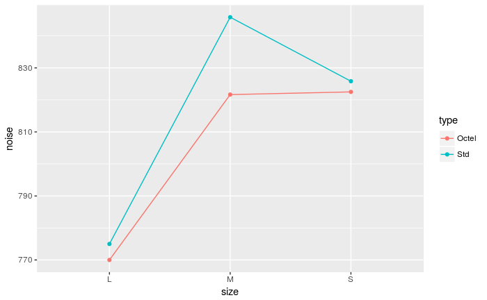

```r
ggplot(autonoise,aes(x=size,y=noise,
    colour=type,group=type))+
  stat_summary(fun.y=mean,geom="point")+
  stat_summary(fun.y=mean,geom="line")
```

The lines are definitely *not* parallel, showing that the effect of `type` is different for medium-sized engines than for others.

### If you don’t like that…

… then compute the means first, in a pipeline:

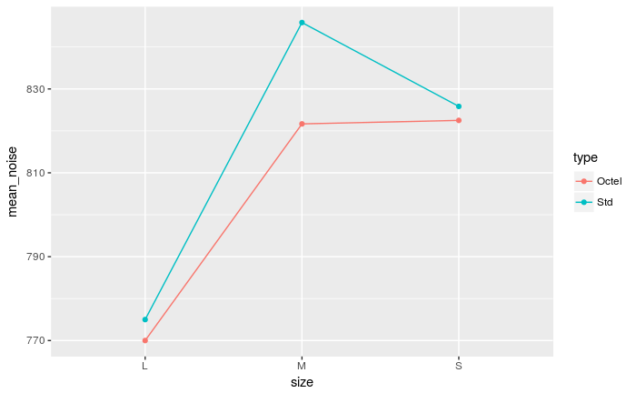

```r
autonoise %>% group_by(size,type) %>%
  summarize(mean_noise=mean(noise)) %>%
  ggplot(aes(x=size,y=mean_noise,group=type,
      colour=type))+geom_point()+geom_line()
```

## Simple effects for auto noise example

- In auto noise example, weren’t interested in all comparisons between car size and filter type combinations.
- Wanted to demonstrate (lack of) difference between filter types *for each engine size*.
- These are called **simple effects** of one variable (filter type) conditional on other variable (engine size).
- To do this, pull out just the data for small engines, compare noise for the two filter types. Then repeat for medium and large cars. (Three one-way ANOVAs.)

Small:

```r
autonoise %>% filter(size=="S") %>%
  aov(noise~type,data=.) %>% summary()
```

```
            Df Sum Sq Mean Sq F value Pr(>F)
type         1   33.3   33.33   0.548  0.476
Residuals   10  608.3   60.83
```

- No filter difference for small-engined cars.
- For Medium, change `S` to `M` and repeat.

```r
autonoise %>% filter(size=="M") %>%
  aov(noise~type,data=.) %>% summary()
```

```
            Df Sum Sq Mean Sq F value   Pr(>F)
type         1 1752.1  1752.1   68.93 8.49e-06 ***
Residuals   10  254.2    25.4
---
Signif. codes:  0 ‘***’ 0.001 ‘**’ 0.01 ‘*’ 0.05 ‘.’ 0.1 ‘ ’ 1
```

- There *is* an effect of filter type for medium-engined cars. Look at means to investigate:

```r
autonoise %>% filter(size=="M") %>%
  group_by(type) %>% summarize(m=mean(noise))
```

| type | m |
| --- | --- |
| Octel | 821.6667 |
| Std | 845.8333 |

- Octel filters produce *less* noise for medium-engined cars.
- Large:

```r
autonoise %>% filter(size=="L") %>%
  aov(noise~type,data=.) %>% summary()
```

```
            Df Sum Sq Mean Sq F value Pr(>F)
type         1     75      75   0.682  0.428
Residuals   10   1100     110
```

- No significant difference again.
- Or use `glance` from `broom`:

```r
autonoise %>% filter(size=="L") %>%
  aov(noise~type,data=.) %>% glance()
```

| r.squared | adj.r.squared | sigma | statistic | p.value | df | logLik | AIC | BIC | deviance | df.residual |
| --- | --- | --- | --- | --- | --- | --- | --- | --- | --- | --- |
| 0.06382979 | -0.02978723 | 10.48809 | 0.6818182 | 0.428221 | 2 | -44.13622 | 94.27243 | 95.72715 | 1100 | 10 |

### All at once, using split/apply/combine

Remind ourselves of data layout:

```r
autonoise
```

| noise | size | type | side |
| --- | --- | --- | --- |
| 840 | M | Std | R |
| 770 | L | Octel | L |
| 820 | M | Octel | R |
| 775 | L | Octel | R |
| 825 | M | Octel | L |
| 840 | M | Std | R |
| 845 | M | Std | L |
| 825 | M | Octel | L |
| 815 | M | Octel | L |
| 845 | M | Std | R |

[output cut: 26 more lines]

The “split” part:

```r
autonoise %>% group_by(size) %>%
    nest()
```

| size | data |
| --- | --- |
| M |  |
| L |  |
| S |  |

Now have *three* rows, with the data frame for each size encoded as *one element* of this data frame.

Apply:

- Write function to do `aov` on a data frame with columns `noise` and `type`, returning P-value:

```r
aov_pval=function(x) {
    noise.1=aov(noise~type,data=x)
    gg=glance(noise.1)
    gg$p.value
}
```

- Test it:

```r
autonoise %>% filter(size=="L") %>%
  aov_pval()
```

```
[1] 0.428221
```

- Check.

Combine:

- Apply this function to each of the nested data frames (one per engine size):

```r
autonoise %>% group_by(size) %>%
    nest()
```

| size | data |
| --- | --- |
| M |  |
| L |  |
| S |  |

```r
autonoise %>% group_by(size) %>%
    nest() %>%
    mutate(p_val=map_dbl(data,aov_pval))
```

| size | data | p_val |
| --- | --- | --- |
| M |  | 8.492967e-06 |
| L |  | 4.282210e-01 |
| S |  | 4.761786e-01 |

- `map_dbl` because `aov_pval` returns a decimal number (a `dbl`). Investigate what happens if you use `map` instead:

```r
autonoise %>% group_by(size) %>%
    nest() %>%
    mutate(p_val=map(data,aov_pval))
```

| size | data | p_val |
| --- | --- | --- |
| M |  |  |
| L |  |  |
| S |  |  |

We don’t get to see the P-values; we need one more step to get them out:

```r
autonoise %>% group_by(size) %>%
    nest() %>%
    mutate(p_val=map(data,aov_pval)) %>%
    unnest(p_val)
```

| size | data | p_val |
| --- | --- | --- |
| M |  | 8.492967e-06 |
| L |  | 4.282210e-01 |
| S |  | 4.761786e-01 |

- The `data` column was stepping-stone to getting answer. Don’t need it any more:

```r
simple_effects = autonoise %>% group_by(size) %>%
    nest() %>%
    mutate(p_val=map_dbl(data,aov_pval)) %>%
    select(-data)
simple_effects
```

| size | p_val |
| --- | --- |
| M | 8.492967e-06 |
| L | 4.282210e-01 |
| S | 4.761786e-01 |

### Simultaneous tests

- When testing simple effects, doing several tests at once. (In this case, 3.)
- Have to adjust P-values for this. Eg. Holm:

```r
simple_effects %>%
    arrange(p_val) %>%
    mutate(multiplier=4-row_number()) %>%
    mutate(p_val_adj=p_val*multiplier)
```

| size | p_val | multiplier | p_val_adj |
| --- | --- | --- | --- |
| M | 8.492967e-06 | 3 | 0.0000254789 |
| L | 4.282210e-01 | 2 | 0.8564419461 |
| S | 4.761786e-01 | 1 | 0.4761785895 |

- No change in rejection decisions.
- Octel filters sig. better in terms of noise for medium cars, and not sig. different for other sizes.
- Octel filters never significantly worse than standard ones.

### Confidence intervals

- Perhaps better way of assessing simple effects: look at *confidence intervals* rather than tests.
- Gives us sense of accuracy of estimation, and thus whether non-significance might be lack of power: “absence of evidence is not evidence of absence”.
- Works here because *two* filter types, using `t.test` for each engine type.
- Want to show that the Octel filter is equivalent to or better than the standard filter, in terms of engine noise.

### CI for small cars

Same idea as for simple effect test:

```r
autonoise %>% filter(size=="S") %>%
  t.test(noise~type,data=.) %>% glance() %>%
  select(conf.low,conf.high)
```

| conf.low | conf.high |
| --- | --- |
| -14.51746 | 7.850795 |

### CI for medium cars

```r
autonoise %>% filter(size=="M") %>%
  t.test(noise~type,data=.) %>% glance() %>%
  select(conf.low,conf.high)
```

| conf.low | conf.high |
| --- | --- |
| -30.75784 | -17.57549 |

CI for large:

```r
autonoise %>% filter(size=="L") %>%
  t.test(noise~type,data=.) %>%
  glance() %>%
  select(conf.low,conf.high)
```

| conf.low | conf.high |
| --- | --- |
| -19.27067 | 9.270673 |

Or, all at once: split/apply/combine

```r
ci_func=function(x) {
    tt=t.test(noise~type,data=x) %>%
      glance() %>%
      select(conf.low,conf.high)
}
autonoise %>%
    group_by(size) %>% nest() %>%
    mutate(ci=map(data,ci_func)) %>%
    unnest(ci)
```

| size | data | conf.low | conf.high |
| --- | --- | --- | --- |
| M |  | -30.75784 | -17.575492 |
| L |  | -19.27067 | 9.270673 |
| S |  | -14.51746 | 7.850795 |

- Function to get CI of difference in noise means for types of filter on input data frame
- Group by `size`, nest (mini-df per size)
- Calculate CI for each thing in `data` (ie. each `size`). `map`: CI is two numbers long
- `unnest` `ci` column to see two numbers in each CI.

# Contrasts in ANOVA

- Sometimes, don’t want to compare *all* groups, only *some* of them.
- Might be able to specify these comparisons ahead of time; other comparisons of no interest.
- Wasteful to do ANOVA and Tukey.

## Example: chainsaw kickback

```
-  From <http://www.ohio.edu/plantbio/staff/mccarthy/quantmet/lectures/ANOVA2.pdf>.
```

- Forest manager concerned about safety of chainsaws issued to field crew. 4 models of chainsaws, measure “kickback” (degrees of deflection) for 5 of each:
- So far, standard 1-way ANOVA: what differences are there among models?
  - But: models A and D are designed to be used at home, while models B and C are industrial models.
  - Suggests these comparisons of interest:
  - home vs. industrial
  - the two home models A vs. D
  - the two industrial models B vs. C.
  - Don’t need to compare *all* the pairs of models.

## What is a contrast?

- Contrast is a linear combination of group means.
- Notation: $\mu_A$ for (population) mean of group $A$, and so on.
- In example, compare two home models: $H_0: \mu_A-\mu_D=0$.
- Compare two industrial models: $H_0: \mu_B-\mu_C=0$.
- Compare average of two home models vs. average of two industrial models: $H_0: {1\over2}(\mu_A+\mu_D)-{1\over 2}(\mu_B+\mu_C)=0$ or $H_0: 0.5\mu_A-0.5\mu_B-0.5\mu_C+0.5\mu_D=0$.
- Note that coefficients of contrasts add to 0, and right-hand side is 0.

## Contrasts in R

- Comparing two home models A and D ($\mu_A-\mu_D=0$):

```r
c.home=c(1,0,0,-1)
```

- Comparing two industrial models B and C ($\mu_B-\mu_C=0$):

```r
c.industrial=c(0,1,-1,0)
```

- Comparing home average vs. industrial average ($0.5\mu_A-0.5\mu_B-0.5\mu_C+0.5\mu_D=0$):

```r
c.home.ind=c(0.5,-0.5,-0.5,0.5)
```

## Orthogonal contrasts

- What happens if we multiply the contrast coefficients one by one?

```r
c.home*c.industrial
```

```
[1] 0 0 0 0
```

```r
c.home*c.home.ind
```

```
[1]  0.5  0.0  0.0 -0.5
```

```r
c.industrial*c.home.ind
```

```
[1]  0.0 -0.5  0.5  0.0
```

- in each case, the results **add up to zero**. Such contrasts are called **orthogonal**.
- Compare these:

```r
c1=c(1,-1,0)
c1
```

```
[1]  1 -1  0
```

```r
c2=c(0,1,-1)
c2
```

```
[1]  0  1 -1
```

```r
c1*c2
```

```
[1]  0 -1  0
```

Does not add up to zero, so `c1` and `c2` are *not* orthogonal. - Orthogonal contrasts are much easier to deal with.

- Can use non-orthogonal contrasts, but much more trouble (and beyond us).

## Starting the analysis

```r
my_url="http://www.utsc.utoronto.ca/~butler/d29/chainsaw.txt"
chain.wide=read_table(my_url)
chain.wide
```

| A | B | C | D |
| --- | --- | --- | --- |
| 42 | 28 | 57 | 29 |
| 17 | 50 | 45 | 29 |
| 24 | 44 | 48 | 22 |
| 39 | 32 | 41 | 34 |
| 43 | 61 | 54 | 30 |

Need all the kickbacks in *one* column:

```r
chain = chain.wide %>%
  gather(model,kickback,A:D,factor_key=T)
chain
```

| model | kickback |
| --- | --- |
| A | 42 |
| A | 17 |
| A | 24 |
| A | 39 |
| A | 43 |
| B | 28 |
| B | 50 |
| B | 44 |
| B | 32 |
| B | 61 |

[output cut: 10 more lines]

We beed `model` to be factor later, so the `factor_key=T` makes that happen now. (Look carefully at heading for `model` column.)

## Setting up and using contrasts

```r
m=cbind(c.home,c.industrial,c.home.ind)
m
```

```
     c.home c.industrial c.home.ind
[1,]      1            0        0.5
[2,]      0            1       -0.5
[3,]      0           -1       -0.5
[4,]     -1            0        0.5
```

```r
contrasts(chain$model)=m
```

Now run ANOVA *as if regression*:

```r
chain.1=lm(kickback~model,data=chain)
summary(chain.1)
```

```
Call:
lm(formula = kickback ~ model, data = chain)

Residuals:
   Min     1Q Median     3Q    Max
-16.00  -7.10   0.60   6.25  18.00

Coefficients:
                  Estimate Std. Error t value Pr(>|t|)
(Intercept)         38.450      2.179  17.649 6.52e-12 ***
modelc.home          2.100      3.081   0.682  0.50524
modelc.industrial   -3.000      3.081  -0.974  0.34469
modelc.home.ind    -15.100      4.357  -3.466  0.00319 **
---
Signif. codes:  0 ‘***’ 0.001 ‘**’ 0.01 ‘*’ 0.05 ‘.’ 0.1 ‘ ’ 1

Residual standard error: 9.743 on 16 degrees of freedom
Multiple R-squared:  0.4562,    Adjusted R-squared:  0.3542
F-statistic: 4.474 on 3 and 16 DF,  p-value: 0.01833
```

```r
tidy(chain.1) %>% select(term,p.value)
```

| term | p.value |
| --- | --- |
| (Intercept) | 6.518309e-12 |
| modelc.home | 5.052396e-01 |
| modelc.industrial | 3.446913e-01 |
| modelc.home.ind | 3.187219e-03 |

```r
chain %>% group_by(model) %>%
  summarize(mean.kick=mean(kickback))
```

| model | mean.kick |
| --- | --- |
| A | 33.0 |
| B | 43.0 |
| C | 49.0 |
| D | 28.8 |

- Home models A & D have less kickback than industrial ones B & C.
- Makes sense because industrial users should get training to cope with additional kickback.